### Scripts

```r
source("Random forest algorithm.R", local = knitr::knit_global())
source("Predictive performance assessment.R", local = knitr::knit_global())
```

### Dataset

```r
PB_predictors_data <- read.csv("Data/Phase behaviour and descriptors (25 pc step).csv")
```

The dataset was split into a training/testing (`TT_data`) and validation (`V_data`) subset comprising 21 and 7 phase diagrams, respectively. To assess the performance of the selected random forest model structure on unseen data, the `TT_data` was used to train 20 models, while the hold-out `V_data` was used to determine each of the model's generalisation abilibities.

```r
TT_data <- filter(PB_predictors_data, Set == "Training")
V_data <- filter(PB_predictors_data, Set == "Validation")
```

The phase behaviour variable in both datasets was encoded as a factor and a list of of phase behaviour predictor names was created.

```r
TT_data$Phase.behaviour <- factor(as.character(TT_data$Phase.behaviour))
V_data$Phase.behaviour <- factor(as.character(V_data$Phase.behaviour))

predictors_all <- colnames(TT_data[, 3:66][, -(4:6)])
```

### Validation data types

First, the different types of validation phase diagrams (*i.e.*, phase diagrams of systems comprising a previously unseen polar solvent, non-polar solvent or both) and phase behaviour data points (*i.e.* boundary or non-boundary) were defined.

```r
seen_PS <- unique(TT_data$PS)
seen_NPS <- unique(TT_data$NPS)
V_data_unseen_PS <- filter(V_data, !(V_data$PS %in% seen_PS), V_data$NPS %in% seen_NPS)
V_data_unseen_NPS <- filter(V_data, V_data$PS %in% seen_PS, !(V_data$NPS %in% seen_NPS))
V_data_unseen_PS_NPS <- filter(V_data, !(V_data$PS %in% seen_PS), !(V_data$NPS %in%
    seen_NPS))
```

```r
V_data_boundary <- filter(V_data, Phase.boundary == "Boundary")
V_data_nonboundary <- filter(V_data, Phase.boundary == "Non-boundary")
```

### Random forest model training and evaluation

Next, 20 random forest models were trained using the whole `TT_data` dataset and all 61 preprocessed predictors and their performance on the whole `V_data` dataset, as well as on the 5 different `V_data` subsets defined above, was separately assessed.

```r
for (i in seq(1, 120, by = 6)) {
    rf_model <- run_random_forest(TT_data, predictors_all)
    model_performance_validation <- model_performance_assessment(V_data, model_performance_validation,
        rf_model, "Overall", i)
    model_performance_validation <- model_performance_assessment(V_data_boundary,
        model_performance_validation, rf_model, "Boundary", i + 1)
    model_performance_validation <- model_performance_assessment(V_data_nonboundary,
        model_performance_validation, rf_model, "Non-boundary", i + 2)
    model_performance_validation <- model_performance_assessment(V_data_unseen_PS,
        model_performance_validation, rf_model, "Unseen PS", i + 3)
    model_performance_validation <- model_performance_assessment(V_data_unseen_NPS,
        model_performance_validation, rf_model, "Unseen NPS", i + 4)
    model_performance_validation <- model_performance_assessment(V_data_unseen_PS_NPS,
        model_performance_validation, rf_model, "Unseen PS and NPS", i + 5)
}
```

### Predictive performance comparison

The predictive performance of the random forests on the whole hold-out validation data, as well as on the 5 validation data subsets, was compared visually.

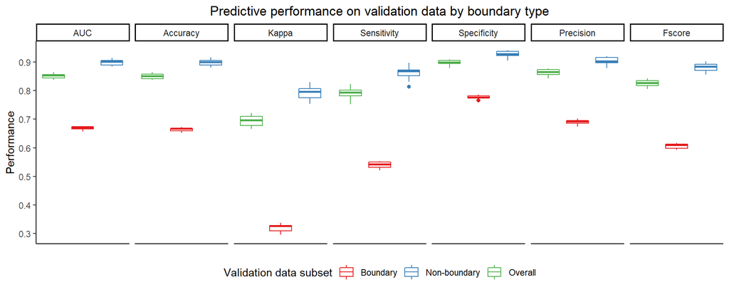

The comparison suggests that the predictive performance of the random forest models is significantly better on data points that are *not* in the "boundary" region (AUC = 0.899 ± 0.010) than on ones that are (AUC = 0.669 ± 0.005). This suggests that the models can generalise the shape on phase diagrams comprising unseen solvents relatively well, however, they have difficulty identifying the exact position of the the phase boundaries.

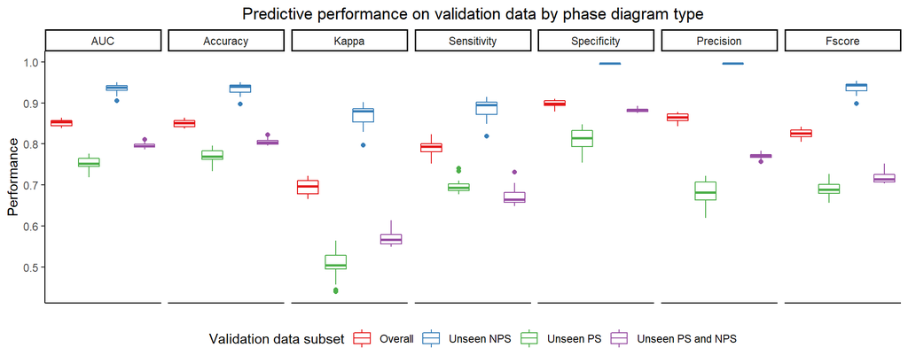

The comparison suggests that the predictions on phase diagrams of systems comprising only an unseen non-polar solvent (NPS) are significantly more accurate (AUC = 0.935 ± 0.011) than those on phase diagrams of systems comprising an unseen polar solvent (PS) either in a combination with a seen or unseen NPS (AUC = 0.752 ± 0.017 and 0.796 ± 0.006, respectively). This points to the more complex influence of PS on the behaviour of the systems and is area of the project, for which imrpovements are currently under way.